# Predicting Health/ Fitness goals using consumer wearable sensing devices

# by Devasena Inupakutika

```python
#Import Libraries
import numpy as np
import pandas as pd
import matplotlib.pyplot as plt
from datetime import datetime
% matplotlib inline
import seaborn as sns
from datetime import timedelta
import csv
import sys, os
from collections import deque
```

### Analysis of Fitbit Wearable Device Data written to csv file

```python
#Read the date-wise data from 5RJHGY_Fitbit.csv file
df = pd.read_csv('Fitbit-5RJHGY-data.csv')
pd.to_datetime(pd.Series(df['Date']), format="%Y-%m-%d")
df.head()
```

|  | Date | Calories Burned | Distance | Floors | Minutes Sedentary | Minutes Lightly Active | Minutes Fairly Active | Minutes Very Active | Activity Calories | Sleep Start Time | Sleep End Time | Minutes Asleep | Minutes Awake | Number of Awakenings | Time in Bed | Minutes REM Sleep | Minutes Light Sleep | Minutes Deep Sleep | Steps |
| --- | --- | --- | --- | --- | --- | --- | --- | --- | --- | --- | --- | --- | --- | --- | --- | --- | --- | --- | --- |
| 0 | 2017-05-30 | 1681 | 2.15 | 0 | 1311 | 117 | 3 | 9 | 467 | NaN | NaN | NaN | NaN | NaN | NaN | NaN | NaN | NaN | 5230 |
| 1 | 2017-05-31 | 1892 | 3.29 | 0 | 1198 | 226 | 7 | 1 | 779 | 2017-05-31 11:51PM | 2017-06-01 6:04AM | 368.0 | 4.0 | 3.0 | 372.0 | NaN | NaN | NaN | 7986 |
| 2 | 2017-06-01 | 1986 | 3.92 | 0 | 810 | 218 | 25 | 23 | 903 | NaN | NaN | NaN | NaN | NaN | NaN | NaN | NaN | NaN | 9714 |
| 3 | 2017-06-02 | 1974 | 4.19 | 0 | 848 | 165 | 41 | 28 | 861 | 2017-06-02 12:04AM | 2017-06-02 6:03AM | 316.0 | 37.0 | 3.0 | 358.0 | NaN | NaN | NaN | 10235 |
| 4 | 2017-06-03 | 2168 | 5.98 | 0 | 1200 | 142 | 29 | 69 | 1062 | NaN | NaN | NaN | NaN | NaN | NaN | NaN | NaN | NaN | 14556 |

We can see missing values as represented by NaN above. Hence, counting the number of missing values per column.

### Data Preprocessing

```python
df.isnull().sum()
```

```
Date                        0
Calories Burned             0
Distance                    0
Floors                      0
Minutes Sedentary           0
Minutes Lightly Active      0
Minutes Fairly Active       0
Minutes Very Active         0
Activity Calories           0
Sleep Start Time          317
Sleep End Time            317
Minutes Asleep            317
Minutes Awake             317
Number of Awakenings      317
Time in Bed               317
Minutes REM Sleep         399
Minutes Light Sleep       399
Minutes Deep Sleep        399
Steps                       0
dtype: int64
```

```python
# fill missing values with mean column values
df.fillna(df.mean(), inplace=True)

# mark zero values as missing or NaN
df['Sleep Start Time'].fillna(0,inplace=True)
df['Sleep End Time'].fillna(0,inplace=True)
df['Minutes REM Sleep'].fillna(0,inplace=True)
df['Minutes Light Sleep'].fillna(0,inplace=True)
df['Minutes Deep Sleep'].fillna(0,inplace=True)

'''
df['Minutes Asleep'].fillna(0,inplace=True)
df['Minutes Awake'].fillna(0,inplace=True)
df['Number of Awakenings'].fillna(0,inplace=True)
df['Time in Bed'].fillna(0,inplace=True)
'''
#df[['Sleep Start Time','Sleep End Time','Minutes Asleep','Minutes Awake','Number of Awakenings','Time in Bed','Minutes REM Sleep','Minutes Light Sleep','Minutes Deep Sleep']] = df[['Sleep Start Time','Sleep End Time','Minutes Asleep','Minutes Awake','Number of Awakenings','Time in Bed','Minutes REM Sleep','Minutes Light Sleep','Minutes Deep Sleep']].replace(0, np.NaN)
df.head()
#df.isnull().sum()
```

|  | Date | Calories Burned | Distance | Floors | Minutes Sedentary | Minutes Lightly Active | Minutes Fairly Active | Minutes Very Active | Activity Calories | Sleep Start Time | Sleep End Time | Minutes Asleep | Minutes Awake | Number of Awakenings | Time in Bed | Minutes REM Sleep | Minutes Light Sleep | Minutes Deep Sleep | Steps |
| --- | --- | --- | --- | --- | --- | --- | --- | --- | --- | --- | --- | --- | --- | --- | --- | --- | --- | --- | --- |
| 0 | 2017-05-30 | 1681 | 2.15 | 0 | 1311 | 117 | 3 | 9 | 467 | 0 | 0 | 248.304878 | 21.829268 | 2.353659 | 271.182927 | 0.0 | 0.0 | 0.0 | 5230 |
| 1 | 2017-05-31 | 1892 | 3.29 | 0 | 1198 | 226 | 7 | 1 | 779 | 2017-05-31 11:51PM | 2017-06-01 6:04AM | 368.000000 | 4.000000 | 3.000000 | 372.000000 | 0.0 | 0.0 | 0.0 | 7986 |
| 2 | 2017-06-01 | 1986 | 3.92 | 0 | 810 | 218 | 25 | 23 | 903 | 0 | 0 | 248.304878 | 21.829268 | 2.353659 | 271.182927 | 0.0 | 0.0 | 0.0 | 9714 |
| 3 | 2017-06-02 | 1974 | 4.19 | 0 | 848 | 165 | 41 | 28 | 861 | 2017-06-02 12:04AM | 2017-06-02 6:03AM | 316.000000 | 37.000000 | 3.000000 | 358.000000 | 0.0 | 0.0 | 0.0 | 10235 |
| 4 | 2017-06-03 | 2168 | 5.98 | 0 | 1200 | 142 | 29 | 69 | 1062 | 0 | 0 | 248.304878 | 21.829268 | 2.353659 | 271.182927 | 0.0 | 0.0 | 0.0 | 14556 |

```python
print("Dimensions of the data collected for last 1 year + starting from May 30, 2017: ",df.shape)
```

```
Dimensions of the data collected for last 1 year + starting from May 30, 2017:  (399, 19)
```

### Dropping the columns that are not required

```python
df.drop(df.columns[[3,9,10,15,16,17]], axis=1, inplace=True)
```

```python
df.head()
```

|  | Date | Calories Burned | Distance | Minutes Sedentary | Minutes Lightly Active | Minutes Fairly Active | Minutes Very Active | Activity Calories | Minutes Asleep | Minutes Awake | Number of Awakenings | Time in Bed | Steps |
| --- | --- | --- | --- | --- | --- | --- | --- | --- | --- | --- | --- | --- | --- |
| 0 | 2017-05-30 | 1681 | 2.15 | 1311 | 117 | 3 | 9 | 467 | 248.304878 | 21.829268 | 2.353659 | 271.182927 | 5230 |
| 1 | 2017-05-31 | 1892 | 3.29 | 1198 | 226 | 7 | 1 | 779 | 368.000000 | 4.000000 | 3.000000 | 372.000000 | 7986 |
| 2 | 2017-06-01 | 1986 | 3.92 | 810 | 218 | 25 | 23 | 903 | 248.304878 | 21.829268 | 2.353659 | 271.182927 | 9714 |
| 3 | 2017-06-02 | 1974 | 4.19 | 848 | 165 | 41 | 28 | 861 | 316.000000 | 37.000000 | 3.000000 | 358.000000 | 10235 |
| 4 | 2017-06-03 | 2168 | 5.98 | 1200 | 142 | 29 | 69 | 1062 | 248.304878 | 21.829268 | 2.353659 | 271.182927 | 14556 |

```python
print("Dimensions of the cleaned dataset: ",df.shape)
```

```
Dimensions of the cleaned dataset:  (399, 13)
```

### Exploratory Data Analysis

#### Feature distributions

```python
print(list(df))
```

```
['Date', 'Calories Burned', 'Distance', 'Minutes Sedentary', 'Minutes Lightly Active', 'Minutes Fairly Active', 'Minutes Very Active', 'Activity Calories', 'Minutes Asleep', 'Minutes Awake', 'Number of Awakenings', 'Time in Bed', 'Steps']
```

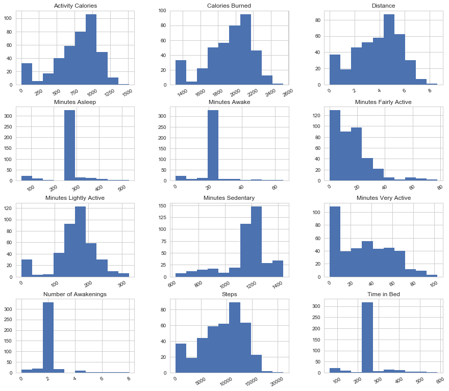

```python
# Looking at the distributions corresponding to each numerical variable in the raw data
df.dtypes
h = df.hist(figsize = (15,20), layout = (6,3), xrot = 30)
plt.savefig('images/raw-data-eda.png', dpi=300)
plt.show()
```

### Looking at correlations

#### Visualizing the important characteristics of a dataset: Observing pair-wise correlations between features

Using the scatter plot below to see how the data is distributed and whether it has any outliers.

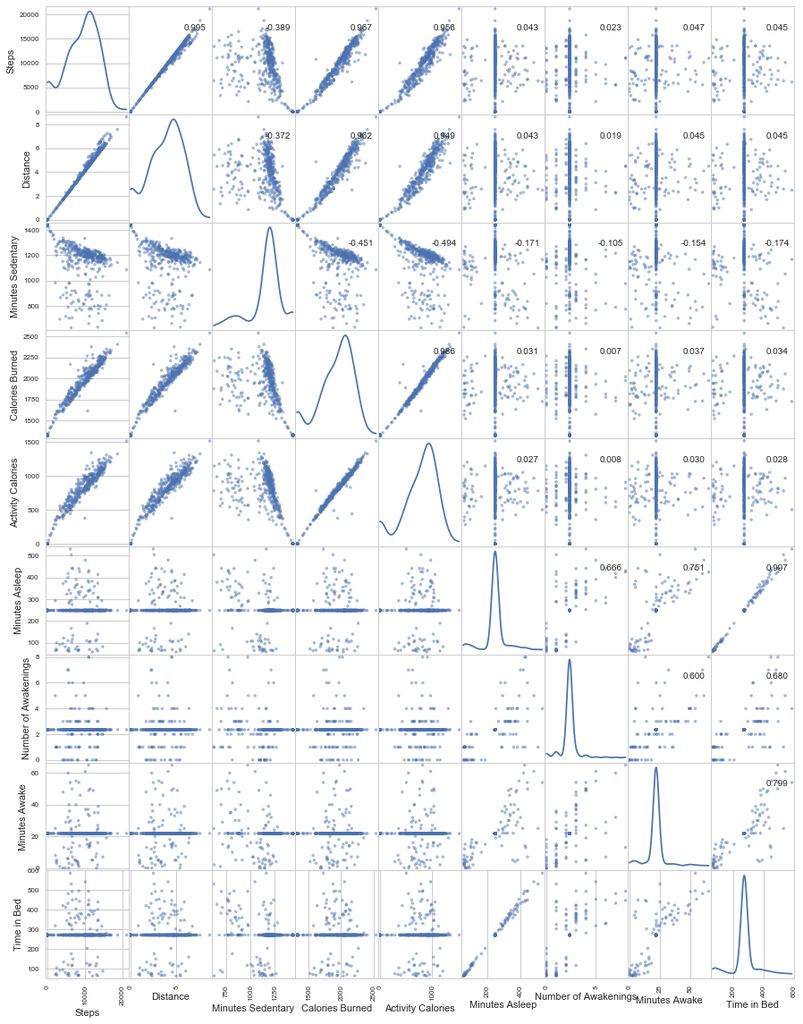

```python
#sns.set(style='whitegrid', context='notebook')
df_partial = df[['Steps','Distance','Minutes Sedentary','Calories Burned','Activity Calories','Minutes Asleep','Number of Awakenings',\
                     'Minutes Awake','Time in Bed']]
axes = pd.scatter_matrix(df_partial, figsize = (15,20), alpha=0.5, diagonal='kde')

corr = df_partial.corr().as_matrix()
for i, j in zip(*plt.np.triu_indices_from(axes, k=1)):
    axes[i, j].annotate("%.3f" %corr[i,j], (0.8, 0.8), xycoords='axes fraction', ha='center', va='center')
#sns.pairplot(df[cols], size=2.5)
plt.savefig('images/pairwise-correlation-matrix.png', dpi=300)
plt.show()
```

### Further Data Munging

```python
# Data cleaning and manipulation

# Create a weekday label which says which day of the week
df['weekday'] = df['Date'].map(lambda x: (datetime.strptime(str(x),"%Y-%m-%d")).weekday() , na_action = 'ignore')
df['day'] = df['Date'].map(lambda x: (datetime.strptime(str(x),"%Y-%m-%d")).date , na_action = 'ignore')
df['month'] = df['Date'].map(lambda x: (datetime.strptime(str(x),"%Y-%m-%d")).month , na_action = 'ignore')
# Percentage of awake time to time in bed (related to efficiency)
df['sleep_awake_per'] = df['Minutes Awake']/df['Time in Bed']*100
```

```python
# Function to clean up plots
def prepare_plot_area(ax):
    # Remove plot frame lines
    ax.spines["top"].set_visible(False)
    ax.spines["right"].set_visible(False)
    ax.spines["left"].set_visible(False)

    # X and y ticks on bottom and left
    ax.get_xaxis().tick_bottom()
    ax.get_yaxis().tick_left()

# Defining a color pattern that is pleasing
colrcode = [(31, 119, 180), (255, 127, 14),\
             (44, 160, 44), (214, 39, 40), \
             (148, 103, 189),  (140, 86, 75), \
             (227, 119, 194), (127, 127, 127), \
             (188, 189, 34), (23, 190, 207)]

for i in range(len(colrcode)):
    r, g, b = colrcode[i]
    colrcode[i] = (r / 255., g / 255., b / 255.)
```

### Data Interaction

Here, we look at the trend shared by predictors, i.e the features that will be used to predict Steps. The correlation matrix is computed and represented as heatmap below:

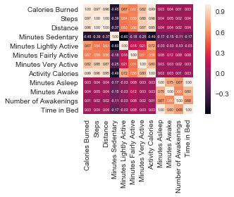

```python
#Plotting correlation matrix as heatmap
cols = ['Calories Burned', 'Steps', 'Distance', 'Minutes Sedentary', 'Minutes Lightly Active', 'Minutes Fairly Active', 'Minutes Very Active', 'Activity Calories', 'Minutes Asleep', 'Minutes Awake', 'Number of Awakenings', 'Time in Bed']
cm = np.corrcoef(df[cols].values.T)
hm = sns.heatmap(cm,
                 cbar=True,
                 annot=True,
                 square=True,
                 fmt='.2f',
                 annot_kws={'size': 5},
                 yticklabels=cols,
                 xticklabels=cols)

plt.tight_layout()
plt.savefig('images/corr_heatmap.png', dpi=300)
plt.show()
```

From above heatmap, we can observe some strong correlation between some sleep predictors. Distance is strongly correlated to Steps and both are inter-correlated to Calories Burned and Activity Calories and also Minutes Very Active, which indicates that my main calorie burn is due to exercise or workout.

### Insights from Data Analysis

My Fitbit Flex2 data shows some strong correlation between predictors such as Distance, Calories burned, Activity Calories and Minutes very active (1.00, 0.97, 0.96 and 0.88 correlation).

#### Relation between Steps and Predictors are as shown in below graphs:

##### Steps Vs Predictors (Distance, Calories Burned and Activity Calories) All in One

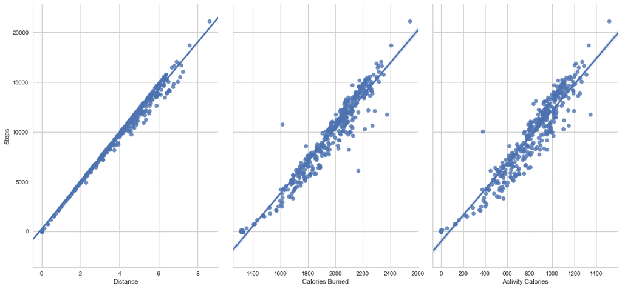

```python
sns.pairplot(df, x_vars=['Distance','Calories Burned','Activity Calories'], y_vars='Steps', size=7, aspect=0.7, kind='reg')
plt.savefig('images/allinonestepsvspred.png', dpi=300)
```

##### Step Variations, Sleep Minutes and Sleep Inefficiency based on Week Days

```python
# Looking at variations based on weekday
steps_weekday = df['Steps'].groupby(df['weekday']).median()
sleep_minutes_asleep_med = df['Minutes Asleep'].groupby(df['weekday']).median()/60
sleep_eff = (1-df['Minutes Asleep']/df['Time in Bed'])*100
sl = sleep_eff.groupby(df['weekday']).median()
```

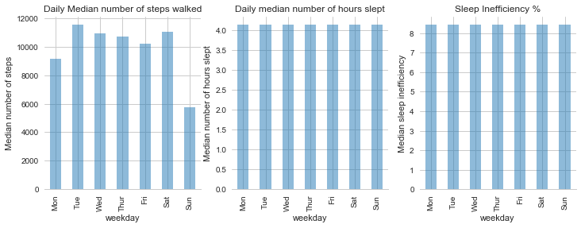

```python
# Median number of steps
fig,axes = plt.subplots(figsize=(12, 4), nrows=1, ncols=3)

ct = 0
plt.sca(axes[ct])
steps_weekday.plot(kind = 'bar',color = colrcode[0], alpha = 0.5)
plt.ylabel('Median number of steps')
plt.title('Daily Median number of steps walked')
plt.xticks(list(range(7)),['Mon','Tue','Wed','Thur','Fri','Sat','Sun'])
prepare_plot_area(axes[ct])

# Median number of minutes slept
ct +=1
plt.sca(axes[ct])
sleep_minutes_asleep_med.plot(kind = 'bar',color = colrcode[0], alpha = 0.5)
plt.ylabel('Median number of hours slept')
plt.title('Daily median number of hours slept')
plt.xticks(list(range(7)),['Mon','Tue','Wed','Thur','Fri','Sat','Sun'])
prepare_plot_area(axes[ct])

ct +=1
plt.sca(axes[ct])
sl.plot(kind = 'bar',color = colrcode[0], alpha = 0.5)
plt.ylabel('Median sleep inefficiency')
plt.title('Sleep Inefficiency %')
plt.xticks(list(range(7)),['Mon','Tue','Wed','Thur','Fri','Sat','Sun'])
prepare_plot_area(axes[ct])
plt.savefig('images/Steps-sleep-weekday.png', dpi=300)
```

##### Correlation between Step Count and Sleep Inefficiency

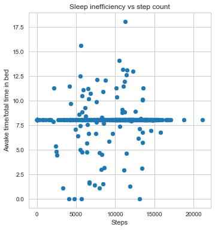

```python
fig = plt.figure(figsize = (12,6))
ax = fig.add_subplot(121)
ax.scatter(df['Steps'],df['sleep_awake_per'],color = colrcode[0])
plt.xlabel('Steps')
plt.ylabel('Awake time/total time in bed')
plt.title('Sleep inefficiency vs step count')
plt.savefig('images/sleepineff-steps.png', dpi=300)
```

### Steps Prediction and Evaluation

Since the target variable is **Steps** here. In order to predict **Steps**, we split our data into train (70%) and test (30%) datasets.

#### Simple Linear Regression Model

```python
from sklearn.cross_validation import train_test_split
import statsmodels.formula.api as smf
from sklearn.linear_model import LinearRegression
from sklearn import metrics

X_train, X_test, y_train, y_test = train_test_split(X,y,test_size=0.30,random_state=0)

#Starting it with one feature currently called 'Distance' because of correlation r =1 and estimating the coefficient
# create X and y
feature_cols = ['Distance']
X = df[feature_cols]
y = df.Steps

# instantiate and fit
slr = LinearRegression()
slr.fit(X, y)

# print the coefficients
print(slr.intercept_)
print(slr.coef_)

### STATSMODELS ###

# create a fitted model
lm1 = smf.ols(formula='Steps ~ Distance', data=df).fit()

# print the coefficients
lm1.params
```

```
215.19331101352327
[2349.72926778]
```

```
Intercept     215.193311
Distance     2349.729268
dtype: float64
```

#### Using the model for prediction:

y = 215.1933 + 2349.729 * x

```python
#For distance of 5 miles
slr.predict(5)
```

```
array([11963.83964993])
```

```python
### STATSMODELS ###

# We have to create a DataFrame since the Statsmodels formula interface expects it
X_new = pd.DataFrame({'Distance': [5]})

# predict for a new observation
lm1.predict(X_new)
```

```
0    11963.83965
dtype: float64
```

#### Plotting the least squares line

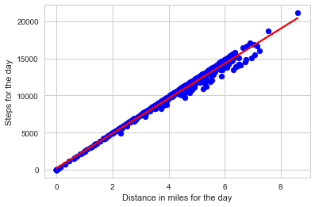

```python
def lin_regplot(X,y,model):
    plt.scatter(X,y,c="blue")
    plt.plot(X,model.predict(X),color="red")
    return None

lin_regplot(X,y,slr)
plt.xlabel("Distance in miles for the day")
plt.ylabel("Steps for the day")
plt.savefig('images/lin-reg.png', dpi=300)
plt.show()
```

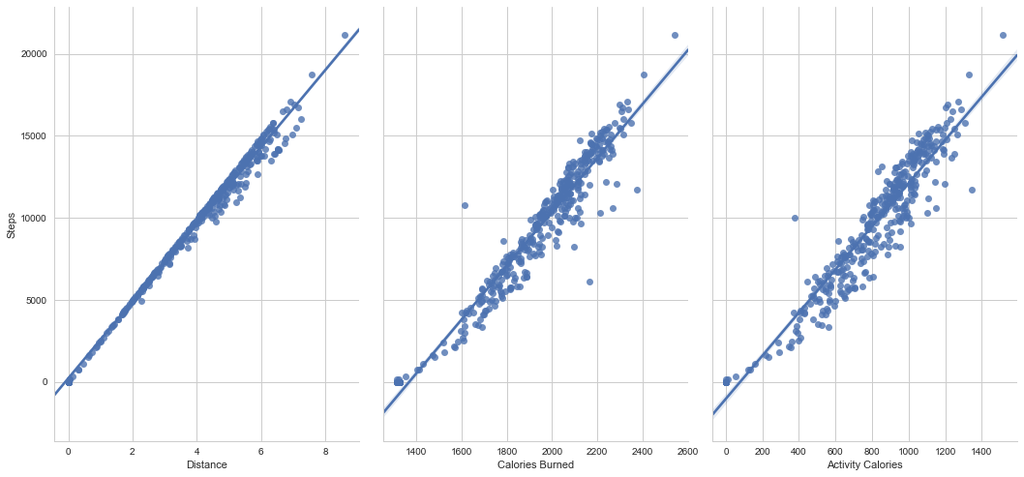

```python
sns.pairplot(df, x_vars=['Distance','Calories Burned','Activity Calories'], y_vars='Steps', size=7, aspect=0.7, kind='reg')
plt.savefig('images/stepsvspred-model.png', dpi=300)
```

#### Assessing variable importance using linear regression and test p-values for each predictor

```python
# print the p-values for the model coefficients for Distance Predictor
lm1.pvalues

#p-values for other variables and predictors

### STATSMODELS for Calories Burned###
#Removing space between columns
df=df.rename(columns={"Calories Burned":"Calories_Burned", "Activity Calories":"Activity_Calories","Minutes Very Active":"Minutes_Very_Active","Minutes Awake":"Minutes_Awake","Time in Bed":"Time_in_Bed","Minutes Asleep":"Minutes_Asleep"})
```

```python
df
```

[output not shown]

399 rows × 17 columns

```python
### STATSMODELS for calories_burned ###

# create a fitted model
lm11 = smf.ols(formula='Steps ~ Calories_Burned', data=df).fit()

# print the coefficients
lm11.params

### STATSMODELS ###

# We have to create a DataFrame since the Statsmodels formula interface expects it
X_new1 = pd.DataFrame({'Calories_Burned': [2000]})

# predict for a new observation
lm11.predict(X_new1)
# print the p-values for the model coefficients for Distance Predictor
lm11.pvalues
```

```
Intercept          4.626848e-183
Calories_Burned    4.064068e-238
dtype: float64
```

```python
### STATSMODELS for Activity_Calories ###

# create a fitted model
lm12 = smf.ols(formula='Steps ~ Activity_Calories', data=df).fit()

# print the coefficients
lm12.params

### STATSMODELS ###

# We have to create a DataFrame since the Statsmodels formula interface expects it
X_new2 = pd.DataFrame({'Activity_Calories': [1000]})

# predict for a new observation
lm12.predict(X_new2)
# print the p-values for the model coefficients for Calories Burned Predictor
lm12.pvalues
```

```
Intercept             2.119603e-09
Activity_Calories    2.865917e-214
dtype: float64
```

```python
### STATSMODELS for Minutes_Very_Active ###

# create a fitted model
lm13 = smf.ols(formula='Steps ~ Minutes_Very_Active', data=df).fit()

# print the coefficients
lm13.params

### STATSMODELS ###

# We have to create a DataFrame since the Statsmodels formula interface expects it
X_new3 = pd.DataFrame({'Minutes_Very_Active': [60]})

# predict for a new observation
lm13.predict(X_new3)
# print the p-values for the model coefficients for Minutes very active Predictor
lm13.pvalues
```

```
Intercept               4.930023e-84
Minutes_Very_Active    5.748666e-128
dtype: float64
```

```python
### STATSMODELS for sleep_awake_per ###

# create a fitted model
lm14 = smf.ols(formula='Steps ~ sleep_awake_per', data=df).fit()

# print the coefficients
lm14.params

### STATSMODELS ###

# We have to create a DataFrame since the Statsmodels formula interface expects it
X_new4 = pd.DataFrame({'sleep_awake_per': [8.00]})

# predict for a new observation
lm14.predict(X_new4)
# print the p-values for the model coefficients for sleep_awake_per Predictor
lm14.pvalues
```

```
Intercept          1.000395e-14
sleep_awake_per    2.147004e-01
dtype: float64
```

#### How well model fits the data?

```python
slr.score(X,y)
```

```
0.990445703687681
```

```python
### STATSMODELS ###

# print the R-squared value for the model
lm1.rsquared
```

```
0.990445703687681
```

#### Multiple Linear Regression

```python
from sklearn.metrics import r2_score
from sklearn.metrics import mean_squared_error
```

```python
# create X and y
feature_cols = ['Distance', 'Calories_Burned', 'Activity_Calories','sleep_awake_per']
X = df[feature_cols]
y = df.Steps

# instantiate and fit
slr2 = LinearRegression()
slr2.fit(X, y)

# print the coefficients
print(slr2.intercept_)
print(slr2.coef_)
# pair the feature names with the coefficients
list(zip(feature_cols, slr2.coef_))
slr2.score(X,y)
```

```
-1057.9283169964856
[2.05827285e+03 7.02975896e-01 1.20758555e+00 1.15121071e+01]
```

```
0.9918567000076867
```

```python
lm14.summary()
```

OLS Regression Results

| Dep. Variable: | Steps | R-squared: | 0.004 |
| --- | --- | --- | --- |
| Model: | OLS | Adj. R-squared: | 0.001 |
| Method: | Least Squares | F-statistic: | 1.544 |
| Date: | Sat, 07 Jul 2018 | Prob (F-statistic): | 0.215 |
| Time: | 16:05:30 | Log-Likelihood: | -3909.8 |
| No. Observations: | 399 | AIC: | 7824. |
| Df Residuals: | 397 | BIC: | 7831. |
| Df Model: | 1 |  |  |
| Covariance Type: | nonrobust |  |  |

|  | coef | std err | t | P>\|t\| | [0.025 | 0.975] |
| --- | --- | --- | --- | --- | --- | --- |
| Intercept | 7987.4807 | 992.741 | 8.046 | 0.000 | 6035.794 | 9939.168 |
| sleep_awake_per | 151.5168 | 121.922 | 1.243 | 0.215 | -88.177 | 391.211 |

| Omnibus: | 17.710 | Durbin-Watson: | 1.140 |
| --- | --- | --- | --- |
| Prob(Omnibus): | 0.000 | Jarque-Bera (JB): | 18.239 |
| Skew: | -0.493 | Prob(JB): | 0.000110 |
| Kurtosis: | 2.645 | Cond. No. | 37.5 |

Warnings:  
[1] Standard Errors assume that the covariance matrix of the errors is correctly specified.

#### Evaluating Multiple Regression Model

```python
feature_cols = ['Distance', 'Calories_Burned', 'Activity_Calories','sleep_awake_per']
X = df[feature_cols]
y = df.Steps
X_train, X_test, y_train, y_test = train_test_split(X,y,test_size=0.30,random_state=0)
# instantiate and fit
slr3 = LinearRegression()
slr3.fit(X_train, y_train)

y_train_pred = slr3.predict(X_train)
y_test_pred = slr3.predict(X_test)
print('MSE train: %.3f, test: %.3f' % (
        mean_squared_error(y_train, y_train_pred),
        mean_squared_error(y_test, y_test_pred)))
print('R^2 train: %.3f, test: %.3f' % (
        r2_score(y_train, y_train_pred),
        r2_score(y_test, y_test_pred)))
```

```
MSE train: 150409.453, test: 168564.853
R^2 train: 0.992, test: 0.991
```

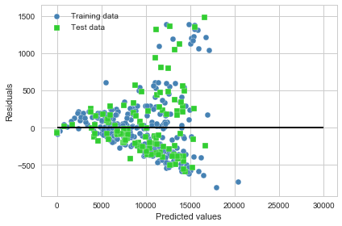

```python
plt.scatter(y_train_pred,  y_train_pred - y_train,
            c='steelblue', marker='o', edgecolor='white',
            label='Training data')
plt.scatter(y_test_pred,  y_test_pred - y_test,
            c='limegreen', marker='s', edgecolor='white',
            label='Test data')
plt.xlabel('Predicted values')
plt.ylabel('Residuals')
plt.legend(loc='upper left')
plt.hlines(y=0,xmin=0,xmax=30000, color='black', lw=2)
plt.tight_layout()

plt.savefig('images/eval_multiple_linear_regression_model-Residual-Plot.png', dpi=300)
plt.show()
```

#### Using Regularized Methods for Regression (to tackle problems of Overfitting)

#### Ridge Regression Model (L2 Penalized Model)

```python
from sklearn.linear_model import Ridge
```

```
MSE train: 150634.735, test: 167937.944
R^2 train: 0.992, test: 0.991
```

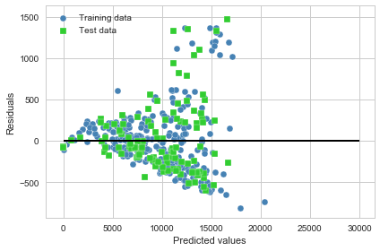

```
0.9918277596036082
```

```python
ridge=Ridge(alpha=1.0)
ridge.fit(X_train, y_train)

y_train_pred = ridge.predict(X_train)
y_test_pred = ridge.predict(X_test)
print('MSE train: %.3f, test: %.3f' % (
        mean_squared_error(y_train, y_train_pred),
        mean_squared_error(y_test, y_test_pred)))
print('R^2 train: %.3f, test: %.3f' % (
        r2_score(y_train, y_train_pred),
        r2_score(y_test, y_test_pred)))
plt.scatter(y_train_pred,  y_train_pred - y_train,
            c='steelblue', marker='o', edgecolor='white',
            label='Training data')
plt.scatter(y_test_pred,  y_test_pred - y_test,
            c='limegreen', marker='s', edgecolor='white',
            label='Test data')
plt.xlabel('Predicted values')
plt.ylabel('Residuals')
plt.legend(loc='upper left')
plt.hlines(y=0,xmin=0,xmax=30000, color='black', lw=2)
plt.tight_layout()

plt.savefig('images/Ridge-Residual-Plot.png', dpi=300)
plt.show()
slr3.score(X,y)
```

```python
ridge.score(X,y)
```

```
0.991829385760251
```

#### LASSO Regression Model

```
MSE train: 150634.735, test: 167937.944
R^2 train: 0.992, test: 0.991
```

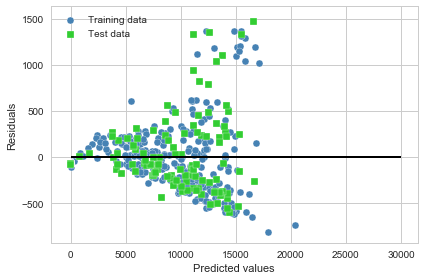

```
0.9918299540652497
```

```python
from sklearn.linear_model import Lasso
lasso=Lasso(alpha=1.0)
lasso.fit(X_train, y_train)

y_train_pred = ridge.predict(X_train)
y_test_pred = ridge.predict(X_test)
print('MSE train: %.3f, test: %.3f' % (
        mean_squared_error(y_train, y_train_pred),
        mean_squared_error(y_test, y_test_pred)))
print('R^2 train: %.3f, test: %.3f' % (
        r2_score(y_train, y_train_pred),
        r2_score(y_test, y_test_pred)))
plt.scatter(y_train_pred,  y_train_pred - y_train,
            c='steelblue', marker='o', edgecolor='white',
            label='Training data')
plt.scatter(y_test_pred,  y_test_pred - y_test,
            c='limegreen', marker='s', edgecolor='white',
            label='Test data')
plt.xlabel('Predicted values')
plt.ylabel('Residuals')
plt.legend(loc='upper left')
plt.hlines(y=0,xmin=0,xmax=30000, color='black', lw=2)
plt.tight_layout()

plt.savefig('images/Lasso-Residual-Plot.png', dpi=300)
plt.show()
lasso.score(X,y)
```

#### Random Forest Regression

```
MSE train: 27928.392, test: 205092.993
R^2 train: 0.999, test: 0.990
```

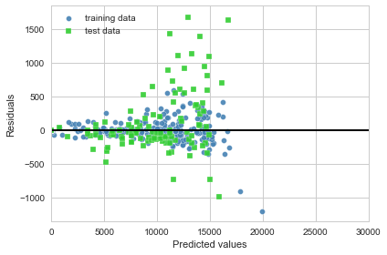

```python
from sklearn.ensemble import RandomForestRegressor
forest = RandomForestRegressor(n_estimators=1000,criterion="mse",random_state=1,n_jobs=-1)
forest.fit(X_train,y_train)
y_train_pred=forest.predict(X_train)
y_test_pred=forest.predict(X_test)
print('MSE train: %.3f, test: %.3f' % (
        mean_squared_error(y_train, y_train_pred),
        mean_squared_error(y_test, y_test_pred)))
print('R^2 train: %.3f, test: %.3f' % (
        r2_score(y_train, y_train_pred),
        r2_score(y_test, y_test_pred)))
plt.scatter(y_train_pred,
            y_train_pred - y_train,
            c='steelblue',
            edgecolor='white',
            marker='o',
            s=35,
            alpha=0.9,
            label='training data')
plt.scatter(y_test_pred,
            y_test_pred - y_test,
            c='limegreen',
            edgecolor='white',
            marker='s',
            s=35,
            alpha=0.9,
            label='test data')

plt.xlabel('Predicted values')
plt.ylabel('Residuals')
plt.legend(loc='upper left')
plt.hlines(y=0, xmin=0, xmax=30000, lw=2, color='black')
plt.xlim([0, 30000])
plt.tight_layout()
plt.savefig('images/forest_regression_plot.png', dpi=300)
plt.show()
```